# Evaluación Final BIO4022

10/10/2019

## Diabetes

La diabetes es una enfermedad crónica donde el páncreas no presenta la capacidad de secretar los niveles de Insulina necesarios para la captación de la glucosa en la sangre. Existen dos tipos de diabetes:

- Diabetes mellitus 1: la cual se genera por una ingesta calorica elevada y constante en el tiempo que tiene como efecto un alza en los niveles de azúcar en la sangre, el cual no es capaz de ser regulado por los niveles de insulina secretado por el páncreas.
- Diabetes tipo 2: sus antecedentes tienen un componente genético, donde las células del páncreas secreto poco o nada de insulina.
- En EEUU durante los años 1990 y 2009 hubo un alza en el número de casos diagnosticados con diabetes, lo que es de gran preocupación a problemas de salud pública.

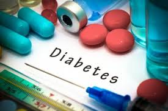

## Análisis de datos

En este trabajo nos centraremos en el estudio de la base de datos *Diabetes 130 US hospitals for years 1999-2008* Diabetes 130 US hospitals for years 1999-2008 que concentra la informacion de varios pacientes ingresados a la clínica y que fueron diagnosticados con diabetes y la siguiente información: Edad, Raza, Media_Tiempo_en_clínica, Número_procedimientos_lab, Número_procedimientos, Número_medicamentos.

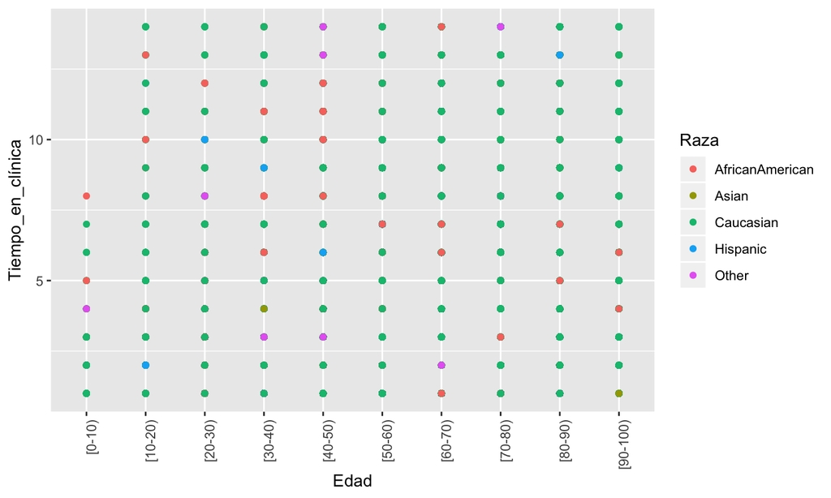

Si realizamos un gráfico poniendo en el eje de la abscisa la Edad y en el eje de la ordena el Tiempo en la clínica agrupado de acuerdo a la Raza, se obtiene un grafico que no nos indica mucha información.

## Datos agrupados

Tabla 1: Pacientes con diabetes de acuerdo a su Raza y la media del tiempo de permanencia en clínica, el número de procedimientos realizados y el número de medicamnetos administrados durante la permanencia en la clínica.

| Raza | Media_Tiempo_en_clínica | Media_Número_procedimientos_lab | Media_Número_medicamentos |
| --- | --- | --- | --- |
| AfricanAmerican | 4.17 | 43.60 | 13.08 |
| Asian | 3.49 | 40.61 | 11.33 |
| Caucasian | 3.94 | 42.81 | 13.72 |
| Hispanic | 3.92 | 41.74 | 12.20 |
| Other | 3.85 | 44.58 | 12.79 |

## Nuevo gráfico

Si realizamos otro tipo de represntacion gráfica de los datos:

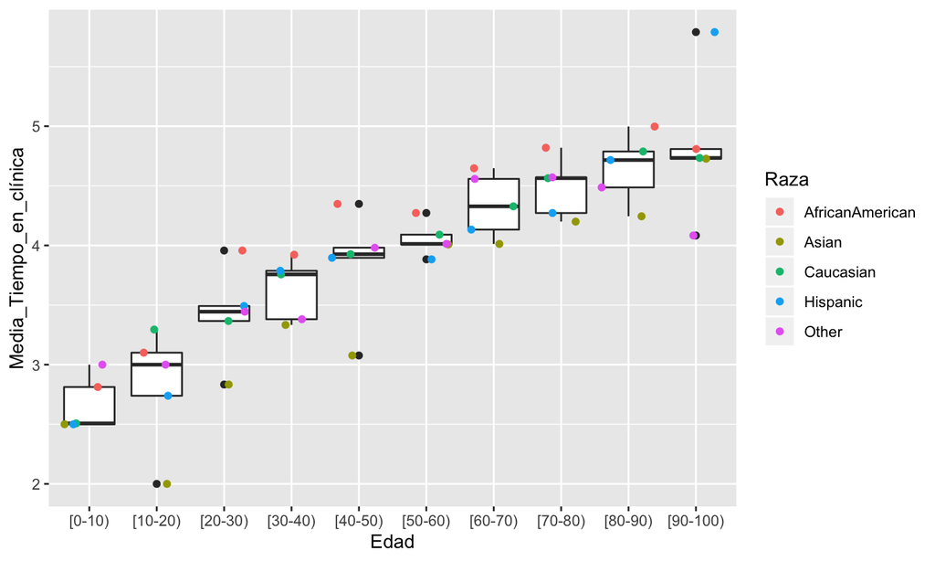

A partir de este gráfico se observa una tendencia de que la Media del Tiempo en clínica aumenta a medida que progresa la edad de los pacientes.

## Modelo

De acuerdo a la representación de los datos anteriores podemos sugerir los siguientes modelos

Tabla 2: Análisis de los modelos propuestos.

| r.squared | p.value | logLik | AIC | BIC | deviance |
| --- | --- | --- | --- | --- | --- |
| 0.90 | 0 | -1.41 | 32.81 | 61.49 | 3.10 |
| 0.82 | 0 | -15.66 | 53.32 | 74.35 | 5.48 |

## Evaluando si el modelo se ajusta a los datos predecidos

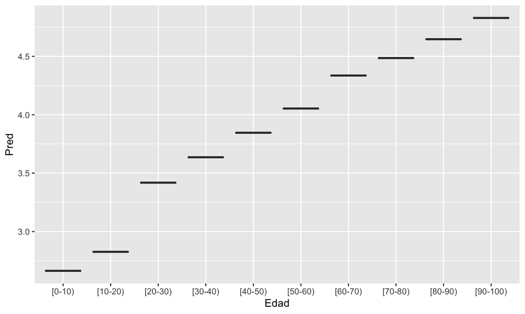

## Referencias

- Beata Strack, Jonathan P. DeShazo, Chris Gennings, et al., “Impact of HbA1c Measurement on Hospital Readmission Rates: Analysis of 70,000 Clinical Database Patient Records,” BioMed Research International, vol. 2014, Article ID 781670, 11 pages, 2014. https://doi.org/10.1155/2014/781670.